# Project 5 - Sheshank

The Plan originally devised to take the scenarios separately and take column by column, check what kind of distribution they are themselves in, then take values either mean, median or mode, that doesn't disturb the distribution (also considering the proportion of missing values and sensitize itself to the maximum variace within the data). For that plan is to create a synthetic data point that encodes what kind of data replacement needs to be done.

Plan is to extend this idea of treatement of NaN to Outliers too. Scaling parameters, won't help with outliers, and they are just a curse that needs to be dealt with.

```python
# Another temporary lambda kind of function, that is envisioned
###############################################################
###############################################################

def replacement_method_appending(dataframe,z_value,case):
    df_out={}
    if case=="fail":
        for item in dataframe.columns:
            if item in z_value[0][1]:
                df_out.update({item:1})
            elif item in z_value[0][0]:
                df_out.update({item:0})
    if case=="pass":
        for item in dataframe.columns:
            if item in z_value[1][1]:
                df_out.update({item:1})
            elif item in z_value[1][0]:
                df_out.update({item:0})
    return df_out
################################################################
###################################################################
s1=replacement_method_appending(x.value,z.value,case="fail")
s2=replacement_method_appending(y.value,z.value,case="pass")
#Codes here 1 for mode, 0 for mean.

print(all(value in s1.keys() for value in s2.keys())) #Checking if those are shared.
```

```
False
```

```python
a.value.append(pd.DataFrame(s1,index=["Method"]))
b.value.append(pd.DataFrame(s2,index=["Method"]))
```

|  | 0 | 1 | 2 | 3 | 4 | 6 | 7 | 8 | 9 | 10 | ... | 580 | 581 | 582 | 583 | 584 | 585 | 586 | 587 | 588 | 589 |
| --- | --- | --- | --- | --- | --- | --- | --- | --- | --- | --- | --- | --- | --- | --- | --- | --- | --- | --- | --- | --- | --- |
| count | 1457.0 | 1457.0 | 1449.0 | 1449.0 | 1449.0 | 1449.0 | 1454.0 | 1461.0 | 1461.0 | 1461.0 | ... | 573.0 | 573.0 | 1462.0 | 1462.0 | 1462.0 | 1462.0 | 1462.0 | 1462.0 | 1462.0 | 1462.0 |
| mean | 3014.947316 | 2495.906115 | 2200.554886 | 1399.290292 | 4.404698 | 101.085773 | 0.12179 | 1.462309 | -0.000715 | 0.000062 | ... | 0.005372 | 98.442837 | 0.500053 | 0.01529 | 0.003841 | 3.063023 | 0.021445 | 0.016392 | 0.00526 | 99.736495 |
| std | 72.461809 | 81.033476 | 29.391944 | 447.984948 | 58.338675 | 6.31748 | 0.009262 | 0.074783 | 0.015207 | 0.009249 | ... | 0.003132 | 89.252336 | 0.003368 | 0.017682 | 0.003833 | 3.684206 | 0.012426 | 0.008822 | 0.002877 | 94.830589 |
| min | 2743.24 | 2158.75 | 2060.66 | 0.0 | 0.6815 | 82.1311 | 0.0 | 1.191 | -0.0534 | -0.0349 | ... | 0.001 | 0.0 | 0.4778 | 0.006 | 0.0017 | 1.1975 | -0.0169 | 0.0032 | 0.001 | 0.0 |
| 25% | 2968.78 | 2452.15 | 2181.1889 | 1081.8758 | 1.016 | 97.7778 | 0.1211 | 1.4103 | -0.0108 | -0.0056 | ... | 0.0034 | 46.1016 | 0.4979 | 0.0116 | 0.0031 | 2.31185 | 0.0134 | 0.0106 | 0.0033 | 44.31625 |
| 50% | 3012.68 | 2499.15 | 2201.0667 | 1285.2144 | 1.3168 | 101.5122 | 0.1224 | 1.4611 | -0.0013 | 0.0003 | ... | 0.0046 | 72.023 | 0.5001 | 0.0138 | 0.0036 | 2.75765 | 0.0205 | 0.0148 | 0.0046 | 71.67665 |
| 75% | 3057.03 | 2539.46 | 2218.0555 | 1591.2235 | 1.5291 | 104.5867 | 0.1238 | 1.5172 | 0.0086 | 0.0058 | ... | 0.0064 | 117.0945 | 0.5023 | 0.0164 | 0.0041 | 3.281525 | 0.0275 | 0.02 | 0.0064 | 114.7497 |
| max | 3356.35 | 2846.44 | 2315.2667 | 3715.0417 | 1114.5366 | 129.2522 | 0.1286 | 1.6564 | 0.0749 | 0.053 | ... | 0.0286 | 737.3048 | 0.5098 | 0.4766 | 0.1045 | 99.3032 | 0.1028 | 0.0799 | 0.0286 | 737.3048 |
| Total_Quartile1 | 364 | 364 | 362 | 358 | 359 | 361 | 357 | 364 | 359 | 360 | ... | 142 | 143 | 359 | 361 | 328 | 366 | 362 | 363 | 326 | 366 |
| Total_Quartile3 | 364 | 364 | 358 | 361 | 356 | 362 | 358 | 364 | 360 | 362 | ... | 141 | 143 | 358 | 362 | 325 | 366 | 363 | 363 | 341 | 363 |
| Method | NaN | NaN | 1 | NaN | NaN | NaN | 1 | NaN | 1 | NaN | ... | 1 | 1 | 1 | 1 | 1 | NaN | 1 | 1 | 1 | 1 |

11 rows × 468 columns

cases :

1. Mode count is comparable to that of the total data entry points : This case implies that that particular column is completely unique. (That column can be marked for mean value subsitution for NaN). If it stops being unique in the alternate scenario, that means they are contendors for failure case prediction. This goes both the ways. We need to monitor them.
2. Mode count is not at all comparable to that of total entry points : This means that we have one single clear modal value further need to check the highest possible mode, and usually carries with it the notion that these particular sensors are the usual sensors. Now, do these change to something else when scenarios change is what needs to be observed.

Mode as high or comparable to the total datapoints indicates that those columns are continuous and unique, are of to be watched out for cross validation in either scenario.

Mode as low or nothing at all, meaning there is only one single mode. But if there are just a few modes, that means there are possible clusters. The special case will be if there are exactly two modes or two clusters formation, indicating pass or fail case scenario.

**Request to the Evaluator** :

We are going down a rabbit hole of data mining here and it is never ending. So, the above simply demonstrates how to to use and analyze various methods to come up with methods for each of the sensors and how to replace values. **Original plan stated before is hereby abandoned**.

**Due to time constraints placed on me, because time is running out, I am going with these three things : 1. Replace NaN values with mode of that particular sensor (which is a very sensible approximation to start with) 2. Replace the outliers (abandoning the idea of replacing them with a specific type of values depending upon the sitatuion and possibilities ) with simply with extreme values (i.e. Threshold value border mentioned in terms of standard deviations). 3. Retaining that idea of discarding those useless sensors and sticking to the dataframe we obtained. I am also seriously loosing sleep, please be considerate.**

# Preliminary Notes

Effort has been made on my part to write a normal cell and also a function method for the same so that in the final stages, we can develop and streamline the whole process for future.

# 0. Data Preparation and Pre-processing

```python
#######################################################################
###### STAGE 0 ########################################################
#######################################################################
```

```python
ddt1=pd.read_csv("signal-data.csv")
ddt1_pass=ddt1[ddt1["Pass/Fail"]==-1]
ddt1_fail=ddt1[ddt1["Pass/Fail"]==1]
ddt1_pass_=ddt1_pass.drop(["Time","Pass/Fail"],axis=1)
ddt1_fail_=ddt1_fail.drop(["Time","Pass/Fail"],axis=1)
```

**Please Note** :

I feel that it is very important to treat Pass case and Fail case scenario as separate for analysis because there are some key indicators from sensors that must be treated in their own right to keep the essence of outcome intact. If we treat them in the single frame, there is a high likelihood that we might loose important information that might be a key deciding factor in the outcome of a particular process.

After pre-processing stage, we can reunite them again to create a clean dataframe for further analysis.

```python
threshold_chosen=3 #This is the master threshold value that is going to go long way
#######################################################################
#######################################################################
def outlier_NaN_treatment(dataframe,threshold): # threshold in terms of no of std deviations something is away.
    df=dataframe
    df_desc=df.describe()
    Q2=df_desc.loc["50%"]
    Q1=Q2-(threshold*df_desc.loc["std"])
    Q3=Q2+(threshold*df_desc.loc["std"])
    for each_col in df.columns:
        #key=False
        #print("\n")
        #print("Column",each_col)
        #print("Quartile 3 Threshold:",Q3.loc[each_col])
        #print("Quartile 1 Threshold:",Q1.loc[each_col])
        col_mode=df[each_col].mode()
        #print("Before Mode :",col_mode)
        col_mode=col_mode.mean() #In case if there are multiple modes, this will level it out.
        #print("Column Mode :",col_mode)
        df[each_col].fillna(value=col_mode,axis=0,inplace=True)
        ################################################################
        for each_value in df[each_col].values:
            #print(each_value,Q3)
            outlier_above=0
            if each_value>Q3[each_col]:
                outlier_above+=1
                #if any([each_value==ale for ale in list(df[each_col])]) : print("Present")
                #print("The Number of Q3 outliers",(df[each_col]==each_value).sum())
                df[each_col].replace(to_replace=each_value,value=Q3[each_col],inplace=True)
                #if any([each_value!=ale for ale in list(df[each_col])]) : print("Now Removed")
                #The above is for Quartile3 outliers
            if each_value<Q1[each_col]:
                #print("The Number of Q1 outliers",(df[each_col]==each_value).sum())
                df[each_col].replace(to_replace=each_value,value=Q1[each_col],inplace=True)
        ####################################################################
    return df
#######################################################################
#######################################################################
t=outlier_NaN_treatment(ddt1_fail_,threshold=threshold_chosen) #Fail case
r=outlier_NaN_treatment(ddt1_pass_,threshold=threshold_chosen) #Pass case
```

```python
t.describe()
```

|  | 0 | 1 | 2 | 3 | 4 | 5 | 6 | 7 | 8 | 9 | ... | 580 | 581 | 582 | 583 | 584 | 585 | 586 | 587 | 588 | 589 |
| --- | --- | --- | --- | --- | --- | --- | --- | --- | --- | --- | --- | --- | --- | --- | --- | --- | --- | --- | --- | --- | --- |
| count | 104.000000 | 104.000000 | 104.000000 | 104.000000 | 104.000000 | 104.0 | 104.000000 | 104.000000 | 104.000000 | 104.000000 | ... | 104.000000 | 104.000000 | 104.000000 | 104.000000 | 104.000000 | 104.000000 | 104.000000 | 104.000000 | 104.000000 | 104.000000 |
| mean | 3007.410808 | 2495.065968 | 2199.967445 | 1354.321743 | 1.301690 | 100.0 | 101.462916 | 0.122266 | 1.470619 | -0.002608 | ... | 0.005515 | 91.139176 | 0.500696 | 0.015470 | 0.003878 | 3.088065 | 0.021617 | 0.017460 | 0.005590 | 96.511290 |
| std | 88.075388 | 70.950754 | 29.688767 | 337.065046 | 0.330896 | 0.0 | 4.901855 | 0.001871 | 0.059834 | 0.013726 | ... | 0.001844 | 38.845396 | 0.003849 | 0.006212 | 0.001240 | 1.239886 | 0.011315 | 0.007881 | 0.002624 | 71.498934 |
| min | 2848.460000 | 2286.900915 | 2138.877800 | 899.948800 | 0.681500 | 100.0 | 87.278900 | 0.116495 | 1.342100 | -0.034300 | ... | 0.001600 | 0.000000 | 0.491500 | 0.008700 | 0.002200 | 1.746900 | -0.003400 | 0.004200 | 0.001600 | 0.000000 |
| 25% | 2946.120000 | 2457.967500 | 2173.480575 | 1069.645950 | 1.044875 | 100.0 | 99.113300 | 0.121100 | 1.431675 | -0.009650 | ... | 0.005400 | 82.481550 | 0.498350 | 0.011500 | 0.003000 | 2.285700 | 0.015225 | 0.011200 | 0.003700 | 45.619225 |
| 50% | 2989.315000 | 2500.285000 | 2196.688900 | 1281.536800 | 1.305650 | 100.0 | 101.638900 | 0.122200 | 1.468500 | -0.001800 | ... | 0.005400 | 91.459929 | 0.501000 | 0.013800 | 0.003700 | 2.759100 | 0.020550 | 0.016800 | 0.005300 | 76.058550 |
| 75% | 3053.280000 | 2531.060000 | 2218.936075 | 1558.445325 | 1.511100 | 100.0 | 104.113625 | 0.123700 | 1.510125 | 0.005100 | ... | 0.005400 | 91.459929 | 0.503100 | 0.017025 | 0.004200 | 3.392675 | 0.028300 | 0.022000 | 0.007100 | 120.742150 |
| max | 3254.544063 | 2714.300000 | 2290.596233 | 2305.455412 | 2.314819 | 100.0 | 116.626629 | 0.127600 | 1.610700 | 0.027900 | ... | 0.014154 | 260.658787 | 0.508800 | 0.034938 | 0.007901 | 6.985490 | 0.054816 | 0.042490 | 0.013445 | 315.825727 |

8 rows × 590 columns

Now we will try to isolate those sensors which no change in both and fail case scenario with respect to their readings i.e. they show no standard deviaton what so ever.

```python
# This function only gives us the list of such sensors, based on our previous analysis.
#########################################################
###########################################################
def eliminate_useless_sensors(dataframe): #This only works if the values supplied are of float type.
    useless=[]
    for each_col in dataframe.columns:
        if dataframe[each_col].std()==0.0:
            useless.append(each_col)
        elif dataframe[each_col].mode().empty:
            useless.append(each_col)
    return useless
##########################################################
##########################################################
#pass_case_sensors_drop=eliminate_useless_sensors(r)
#fail_case_sensors_drop=eliminate_useless_sensors(t)
useless_common_sensors=list(set(eliminate_useless_sensors(r)).intersection(set(eliminate_useless_sensors(t))))
```

```python
#useless_common_sensors
```

```python
r[useless_common_sensors].describe()
```

|  | 507 | 465 | 261 | 13 | 538 | 314 | 329 | 381 | 260 | 178 | ... | 313 | 256 | 395 | 265 | 315 | 266 | 463 | 372 | 326 | 531 |
| --- | --- | --- | --- | --- | --- | --- | --- | --- | --- | --- | --- | --- | --- | --- | --- | --- | --- | --- | --- | --- | --- |
| count | 1463.0 | 1463.0 | 1463.0 | 1463.0 | 1463.0 | 1463.0 | 1463.0 | 1463.0 | 1463.0 | 1463.0 | ... | 1463.0 | 1463.0 | 1463.0 | 1463.0 | 1463.0 | 1463.0 | 1463.0 | 1463.0 | 1463.0 | 1463.0 |
| mean | 0.0 | 0.0 | 0.0 | 0.0 | 0.0 | 0.0 | 0.0 | 0.0 | 0.0 | 0.0 | ... | 0.0 | 0.0 | 0.0 | 0.0 | 0.0 | 0.0 | 0.0 | 0.0 | 0.0 | 0.0 |
| std | 0.0 | 0.0 | 0.0 | 0.0 | 0.0 | 0.0 | 0.0 | 0.0 | 0.0 | 0.0 | ... | 0.0 | 0.0 | 0.0 | 0.0 | 0.0 | 0.0 | 0.0 | 0.0 | 0.0 | 0.0 |
| min | 0.0 | 0.0 | 0.0 | 0.0 | 0.0 | 0.0 | 0.0 | 0.0 | 0.0 | 0.0 | ... | 0.0 | 0.0 | 0.0 | 0.0 | 0.0 | 0.0 | 0.0 | 0.0 | 0.0 | 0.0 |
| 25% | 0.0 | 0.0 | 0.0 | 0.0 | 0.0 | 0.0 | 0.0 | 0.0 | 0.0 | 0.0 | ... | 0.0 | 0.0 | 0.0 | 0.0 | 0.0 | 0.0 | 0.0 | 0.0 | 0.0 | 0.0 |
| 50% | 0.0 | 0.0 | 0.0 | 0.0 | 0.0 | 0.0 | 0.0 | 0.0 | 0.0 | 0.0 | ... | 0.0 | 0.0 | 0.0 | 0.0 | 0.0 | 0.0 | 0.0 | 0.0 | 0.0 | 0.0 |
| 75% | 0.0 | 0.0 | 0.0 | 0.0 | 0.0 | 0.0 | 0.0 | 0.0 | 0.0 | 0.0 | ... | 0.0 | 0.0 | 0.0 | 0.0 | 0.0 | 0.0 | 0.0 | 0.0 | 0.0 | 0.0 |
| max | 0.0 | 0.0 | 0.0 | 0.0 | 0.0 | 0.0 | 0.0 | 0.0 | 0.0 | 0.0 | ... | 0.0 | 0.0 | 0.0 | 0.0 | 0.0 | 0.0 | 0.0 | 0.0 | 0.0 | 0.0 |

8 rows × 116 columns

```python
t[useless_common_sensors].describe()
```

|  | 507 | 465 | 261 | 13 | 538 | 314 | 329 | 381 | 260 | 178 | ... | 313 | 256 | 395 | 265 | 315 | 266 | 463 | 372 | 326 | 531 |
| --- | --- | --- | --- | --- | --- | --- | --- | --- | --- | --- | --- | --- | --- | --- | --- | --- | --- | --- | --- | --- | --- |
| count | 104.0 | 104.0 | 104.0 | 104.0 | 104.0 | 104.0 | 104.0 | 104.0 | 104.0 | 104.0 | ... | 104.0 | 104.0 | 104.0 | 104.0 | 104.0 | 104.0 | 104.0 | 104.0 | 104.0 | 104.0 |
| mean | 0.0 | 0.0 | 0.0 | 0.0 | 0.0 | 0.0 | 0.0 | 0.0 | 0.0 | 0.0 | ... | 0.0 | 0.0 | 0.0 | 0.0 | 0.0 | 0.0 | 0.0 | 0.0 | 0.0 | 0.0 |
| std | 0.0 | 0.0 | 0.0 | 0.0 | 0.0 | 0.0 | 0.0 | 0.0 | 0.0 | 0.0 | ... | 0.0 | 0.0 | 0.0 | 0.0 | 0.0 | 0.0 | 0.0 | 0.0 | 0.0 | 0.0 |
| min | 0.0 | 0.0 | 0.0 | 0.0 | 0.0 | 0.0 | 0.0 | 0.0 | 0.0 | 0.0 | ... | 0.0 | 0.0 | 0.0 | 0.0 | 0.0 | 0.0 | 0.0 | 0.0 | 0.0 | 0.0 |
| 25% | 0.0 | 0.0 | 0.0 | 0.0 | 0.0 | 0.0 | 0.0 | 0.0 | 0.0 | 0.0 | ... | 0.0 | 0.0 | 0.0 | 0.0 | 0.0 | 0.0 | 0.0 | 0.0 | 0.0 | 0.0 |
| 50% | 0.0 | 0.0 | 0.0 | 0.0 | 0.0 | 0.0 | 0.0 | 0.0 | 0.0 | 0.0 | ... | 0.0 | 0.0 | 0.0 | 0.0 | 0.0 | 0.0 | 0.0 | 0.0 | 0.0 | 0.0 |
| 75% | 0.0 | 0.0 | 0.0 | 0.0 | 0.0 | 0.0 | 0.0 | 0.0 | 0.0 | 0.0 | ... | 0.0 | 0.0 | 0.0 | 0.0 | 0.0 | 0.0 | 0.0 | 0.0 | 0.0 | 0.0 |
| max | 0.0 | 0.0 | 0.0 | 0.0 | 0.0 | 0.0 | 0.0 | 0.0 | 0.0 | 0.0 | ... | 0.0 | 0.0 | 0.0 | 0.0 | 0.0 | 0.0 | 0.0 | 0.0 | 0.0 | 0.0 |

8 rows × 116 columns

Finally, we can observe that these sensors add no value to the computations. They are there only just there to add complexity that's it. So, we are choosing to drop them with no further considerations.

```python
data1_final_pass=r.drop(useless_common_sensors,axis=1)
data1_final_fail=t.drop(useless_common_sensors,axis=1)
```

```python
t=None
r=None
x=None
y=None
#data1_final_fail
#data1_final_pass
```

We have other bunch of useless sensors here as we have deductions from previous rigorous data analysis only had 468 columns. But we are ignoring that fact here, so that those remaining ones and a few others can be dealt with in other regularization methods.

```python
print(any(value!=0 for value in list((data1_final_pass.isna()).isna().sum()))) #checking again if there is any NaN values in the dataframe
print(any(value!=0 for value in list((data1_final_fail.isna()).isna().sum())))
```

```
False
False
```

```python
threshold_chosen=3 #Can vary between 2,3,4, depending on how strict our model is
#
#This function can be directly integrated into our pipeline. This is the cream function
#wraps the above two functions of preprocessing into one single function.
#
########################################################
########################################################
def data_preprocess(dataframe,threshold_given,drop_useless=False):
    df=outlier_NaN_treatment(dataframe,threshold=threshold_given)
    useless=eliminate_useless_sensors(dataframe)
    if drop_useless:
        df=df.drop(useless,axis=1)
        return df
    else:
        return df,useless
#########################################################
#########################################################
```

Now that we have completed different kinds of treatment for different kinds of cases of data, we can go ahead and join those data back into a single data frame again.

```python
# Complete clutter cleaned Dataframe is now generated.
################################################################
data1_final=pd.concat([data1_final_fail,data1_final_pass]).sort_index()
#Our Final dataframe that is ready.
################################################################
data1_final["Pass/Fail"]=data1["Pass/Fail"]
###############################################################

data1_final #Have a look at the dataframe with the given number of columns
```

|  | 0 | 1 | 2 | 3 | 4 | 6 | 7 | 8 | 9 | 10 | ... | 581 | 582 | 583 | 584 | 585 | 586 | 587 | 588 | 589 | Pass/Fail |
| --- | --- | --- | --- | --- | --- | --- | --- | --- | --- | --- | --- | --- | --- | --- | --- | --- | --- | --- | --- | --- | --- |
| 0 | 3030.93 | 2564.00 | 2187.7333 | 1411.126500 | 1.3602 | 97.61330 | 0.1242 | 1.5005 | 0.0162 | -0.00340 | ... | 0.0000 | 0.500500 | 0.011800 | 0.003500 | 2.363000 | 0.018400 | 0.01120 | 0.003300 | 0.0000 | -1 |
| 1 | 3095.78 | 2465.14 | 2230.4222 | 1463.660600 | 0.8294 | 102.34330 | 0.1247 | 1.4966 | -0.0005 | -0.01480 | ... | 208.2045 | 0.501900 | 0.022300 | 0.005500 | 4.444700 | 0.009600 | 0.02010 | 0.006000 | 208.2045 | -1 |
| 2 | 2932.61 | 2559.94 | 2186.4111 | 1698.017200 | 1.5102 | 95.48780 | 0.1241 | 1.4436 | 0.0041 | 0.00130 | ... | 82.8602 | 0.495800 | 0.015700 | 0.003900 | 3.174500 | 0.054816 | 0.04249 | 0.013445 | 82.8602 | 1 |
| 3 | 2988.72 | 2479.90 | 2199.0333 | 909.792600 | 1.3204 | 104.23670 | 0.1217 | 1.4882 | -0.0124 | -0.00330 | ... | 73.8432 | 0.499000 | 0.010300 | 0.002500 | 2.054400 | 0.020200 | 0.01490 | 0.004400 | 73.8432 | -1 |
| 4 | 3032.24 | 2502.87 | 2233.3667 | 1326.520000 | 1.5334 | 100.39670 | 0.1235 | 1.5031 | -0.0031 | -0.00720 | ... | 0.0000 | 0.489997 | 0.066846 | 0.015098 | 13.810268 | 0.020200 | 0.01490 | 0.004400 | 73.8432 | -1 |
| ... | ... | ... | ... | ... | ... | ... | ... | ... | ... | ... | ... | ... | ... | ... | ... | ... | ... | ... | ... | ... | ... |
| 1562 | 2899.41 | 2464.36 | 2179.7333 | 2629.169244 | 1.4843 | 82.55976 | 0.1248 | 1.3424 | -0.0045 | -0.00570 | ... | 203.1720 | 0.498800 | 0.014300 | 0.003900 | 2.866900 | 0.006800 | 0.01380 | 0.004700 | 203.1720 | -1 |
| 1563 | 3052.31 | 2522.55 | 2198.5667 | 1124.659500 | 0.8763 | 98.46890 | 0.1205 | 1.4333 | -0.0061 | -0.00930 | ... | 0.0000 | 0.497500 | 0.013100 | 0.003600 | 2.623800 | 0.006800 | 0.01380 | 0.004700 | 203.1720 | -1 |
| 1564 | 2978.81 | 2379.78 | 2206.3000 | 1110.496700 | 0.8236 | 99.41220 | 0.1208 | 1.4760 | -0.0108 | 0.00235 | ... | 43.5231 | 0.498700 | 0.015300 | 0.004100 | 3.059000 | 0.019700 | 0.00860 | 0.002500 | 43.5231 | -1 |
| 1565 | 2894.92 | 2532.01 | 2177.0333 | 1183.728700 | 1.5726 | 98.79780 | 0.1213 | 1.4622 | -0.0072 | 0.00320 | ... | 93.4941 | 0.500400 | 0.017800 | 0.003800 | 3.566200 | 0.026200 | 0.02450 | 0.007500 | 93.4941 | -1 |
| 1566 | 2944.92 | 2450.76 | 2195.4444 | 2629.169244 | 1.5978 | 85.10110 | 0.1235 | 1.4760 | -0.0108 | 0.00235 | ... | 137.7844 | 0.498700 | 0.018100 | 0.004000 | 3.627500 | 0.011700 | 0.01620 | 0.004500 | 137.7844 | -1 |

1567 rows × 475 columns

# 1. Test Train Split

```python
#######################################################################
###### STAGE 1 ########################################################
#######################################################################
```

```python
global random_state #this will be set for repeatability and will not be disturbed.
random_state=1
#This will be completely fixed and referenced everywhere
########################################################################
from sklearn.model_selection import train_test_split
x=data1_final.drop("Pass/Fail",axis=1) # The rest four columns create our independent columns
y=data1_final["Pass/Fail"]
#######################################################################
X_train, X_test, y_train, y_test = train_test_split(x, y, test_size=0.30, random_state=random_state)
#######################################################################
```

# 2. Feature Engineering

```python
#######################################################################
###### STAGE 2 ########################################################
#######################################################################
```

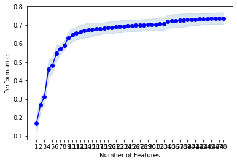

```python
#
# Feature Engineering using sequential feature selection
#
#Here we can modify the features number. Since we have 475 features after
#our preliminary analysis we will restrict ourselves to 48 features i.e. approximately 10%
Number_of_features=48
#######################################################################
from mlxtend.feature_selection import SequentialFeatureSelector as sfs
from mlxtend.plotting import plot_sequential_feature_selection as plot_sfs
from sklearn.linear_model import LinearRegression
from sklearn.metrics import r2_score
######################################################################
# Build Lin Reg  to use in feature selection
linR = LinearRegression()

# Tuning our function. Here you can change the appropriate mechanism.
sfs1 = sfs(linR, k_features=Number_of_features, forward=True, scoring='r2', cv=5)
# Fitting into the Function
sfs1 = sfs1.fit(X_train.values, y_train.values)
selected_ColumnList = [list(X_train.columns)[i] for i in list(sfs1.k_feature_idx_)]

#######################################################################

features=sfs1.get_metric_dict() #get metrics for that particular feature selection method
#pd.DataFrame(features) #Looking at the Dataframe, is 48 good enough ? 42
 # Only choose these columns
plt.figure(figsize=(20,12))
fig = plot_sfs(sfs1.get_metric_dict())
plt.show()
selected_ColumnList = [list(X_train.columns)[i] for i in list(sfs1.k_feature_idx_)]
```

**Note** : We don't have any perfect way or automatic tuning mechanisms for having best features for any given model. So, I am writing a function here that makes use of the most general Linear Regression Model to arrive at best features to be retained, as a preliminary stage, instead of any single feature.

It can always be tweaked. But, I still suggest using PCA for better way of dealing with things.

```python
############################################################################
#
#Writing a function for pipelining mechanism and automation for the same.
#function automatically suggests bets features, trying out every possible combination
#and feature. It starts with 1 and goes all the way to highest number, finds out which
# number makes maximum cumulative difference, and suggests it.
#
############################################################################
###########################################################################
def sequential_feature_selector(X_train,y_train):
    from mlxtend.feature_selection import SequentialFeatureSelector as sfs
    from sklearn.linear_model import LinearRegression
    from sklearn.metrics import r2_score
    ######################################################################
    choice=len(X_train.columns)
    sfs1 = sfs(LinearRegression(), k_features=choice, forward=True, scoring='r2', cv=5)
    # Fitting into the Function
    sfs1=sfs1.fit(X_train.values, y_train.values)
    #print(sfs1.get_metric_dict())
    ###########################################################################
    def select_importance(dataframe,metric="avg_score"):
        minimum_threshold=0.7 #We want features to explain atleast 70 % of data
        df=dataframe.T
        l=df[df[metric]>minimum_threshold][metric]
        ind=l.diff()[l.diff()==l.diff().max()].index
        k=list(df["feature_names"].loc[ind])
        #print(k)
        return list(k[0])
    ############################################################################
    #print(pd.DataFrame(sfs1.get_metric_dict()))
    selected_columns=select_importance(pd.DataFrame(sfs1.get_metric_dict()))
    #print(selected_columns)
    columns_to_drop=[col for col in X_train.columns if col not in selected_columns]
    return X_train[selected_columns],y_train
######################################################################################################
########################################################################################
```

```python
#These are going to be our new data terminals for testing and applying methods.
t=X_train.copy()
r=y_train.copy()
t_test=X_test.copy()
r_test=y_test.copy()
```

```python
#p,q=mf(sequential_feature_selector(t,r))
```

```python
###########################################################################
#
# Using the Decision Tree Regressor to dimensional Reduction.
#
########################################################################
from sklearn.tree import DecisionTreeRegressor
Number_of_features = 48 #We are choosing atleast 10% of our Original features.
######################################################################
regressor = DecisionTreeRegressor(random_state=random_state, max_depth=5)
regressor.fit(t,r)
feature_importances = regressor.feature_importances_
feature_names = t.columns
#print(feature_names)
#print(feature_coef)

#regressor.get_params()
#print(feature_importances)
#print(len(feature_importances))
#print(feature_importances.argsort())
top_k_idx = (feature_importances.argsort()[-Number_of_features:][::-1])
#print(feature_names[top_k_idx], feature_importances)
#print([type(str(x)) for x in top_k_idx])
print(top_k_idx)
#########################################################################
#########################################################################
```

```
[149 303 409 161 150 151 152 153 154 155 156 157 158 159 160 473 162 148
 164 165 166 167 168 169 170 171 172 173 163 147 175 132 120 121 122 123
 124 125 126 127 128 129 130 131 133 146 134 135]
```

```python
#######################################################################
#The same as the above but with a functional form so that can be integrated into pipeline
#This function is tuned to retain atleast 10% of the given features before discarding
# which is a bad idea. But, there is a "percentage" parameters that is going to let us
#decide how many to keep. Sadly I didn't find a method to automatically tune this like before.
#
#########################################################################
#########################################################################
def Decisiontree_feature_engineer(X_train,y_train,percentage=None):
    ########################################################
    from sklearn.tree import DecisionTreeRegressor
      #we can tweak this later on
    #############################################################
    if percentage==None:
        n_features_chosen=X_train.shape[1]*10/100
    else:
        n_features_chosen=X_train.shape[1]*percentage/100
    #############################################################
    regressor = DecisionTreeRegressor(random_state=random_state, max_depth=5)
    regressor.fit(X_train , y_train)
    feature_importances = regressor.feature_importances_
    feature_names = X_train.columns
    #print(feature_names)
    #print(feature_coef)
    #regressor.get_params()
    #print(feature_importances)
    #print(len(feature_importances))
    #print(feature_importances.argsort())
    top_k_idx = (feature_importances.argsort()[-k:][::-1])
    #print(feature_names[top_k_idx], feature_importances)
    return X_train[feature_names[top_k_idx]],y_train
########################################################################
##########################################################################
#p,q=Decisiontree_feature_engineer(t,r)
```

```python
############################################################
# PCA feature reduction and Transformation into the features.
#
#############################################################
from sklearn.decomposition import PCA
#############################################################
#going by the same method of 10% of the features we have chosen this number early on with help from previous analysis.
pca1 = PCA(n_components=Number_of_features)
pca2 = PCA(n_components=Number_of_features)
print("Total Number of Features Chosen :", Number_of_features)
pca1.fit(t)
pca2.fit(t_test)
pca_variance=pca1.explained_variance_ratio_
print("Total Variance Explained by these features are :",pca_variance.sum())
t=pca1.transform(t)
t_test=pca2.transform(t_test)
#Looks like the PCA transformation is going to create wonders with 99 percent explanation of variance.
#############################################################
```

```
Total Number of Features Chosen : 48
Total Variance Explained by these features are : 0.9998226096581223
```

```python
################################################################
#This is the function we have written so that by default it takes
# no any number of components, though if specified by user it abides by it.
# It auto-tunes itself to choose minimum number of features with maximum cumulate
# (or rate change) per increase in the number of features. Method is not rigorous
# but the essense is captured in terms of differences (should be the gradient methods).
# Such differential threshold is given in terms of minimum_threshold variable. We can tune it to purpose it.
#
#############################################################
#############################################################
def PCA_transform_features(X_train,y_train,no_of_components=None):
    ##########################################################
    from sklearn.decomposition import PCA
    #########################################################
    minimum_threshold=0.005 # We can tune this later for whatever value we want for components that can be neglected for their influence
    n=0 #Initialize the number of features to be 0.
###############################################################
    def parameter_tuning(X_train,threshold):
        parameters_to_choose=range(len(X_train.columns))
        decision_maker={}
    ####################################
        for i in parameters_to_choose:
            pca=PCA(n_components=i)
            pca.fit(X_train)
            pca_variance=pca.explained_variance_ratio_.sum()
            decision_maker.update({i:pca_variance})
    ####################################
            #print(decision_maker)
        decision_maker=pd.Series(decision_maker).diff()
        out=decision_maker[decision_maker>threshold].index.max()
        return out
#############################################################
    #print(no_of_components)
    if no_of_components==None:
        n=parameter_tuning(X_train,threshold=minimum_threshold)
        #print("Here in no components")
        #print(n)
    else:
        n=no_of_components
    pca=PCA(n_components=n,random_state=random_state)
    pca.fit(X_train)
    #print(pca.explained_variance_ratio_)
    X_trans=pd.DataFrame(pca.transform(X_train))
    return X_trans,y_train
#############################################################
#############################################################
#completely transformed dataframe is taken.
#We are going it real here and taking on the original data.
X_train,y_train=mf(PCA_transform_features(X_train,y_train))
#x,y=mf(PCA_transform_features(x,y)) Master dataframe Transformation.
```

```
Time taken = 0.8782308101654053 seconds
```

```python
#Just a Small Testing here before we proceed
print(X_train.shape)
print("Here the features are in total are : ",X_train.shape[1])
```

```
(1096, 5)
Here the features are in total are :  5
```

```python
a,b=PCA_transform_features(X_test,y_test,no_of_components=5)
X_test=a
y_test=b
print(X_test.shape) # Checking if the test set changed.
```

```
(471, 5)
```

This total number of features can be noted down now and later used for doing the same transformation on the test set. We could have done it on the master data before going ahead and splitting, that would more equalize the data. But, it is okay for demonstration purposes.

# 3. Sampling and Synthetic Data Generation

```python
#######################################################################
###### STAGE 3 ########################################################
#######################################################################
```

**Please Note** : Synthetic Data generation and sampling is used in final model testing and pipelining. The functional representations do have some error. Please be considerate.

```python
# Refilling the Data with Synthetic points and others while adjusting.
#######################################################
#######################################################
X_train_pass=y_train[y_train==-1].index
X_train_fail=y_train[y_train==1].index
########################################################
#These later merged into a single dataframe after synthetic point generation.
```

```python
######################################################
#Using simple sampling with NumPy
######################################################
import numpy as np
#####################################################
chosen_percentage=60 # We can always set this based on the actual proportion of Pass case and fail case to mange it
######################################################
pass_case_no=len(X_train_pass)
fail_case_no=len(X_train_fail)
total_no=pass_case_no+fail_case_no
chosen_number=( (pass_case_no/total_no)-chosen_percentage)*total_no
if chosen_number<0:
    chosen_number=pass_case_no
#######################################################
random_indices = np.random.choice(X_train_pass, chosen_number)    #Randomly pick up 200 non-diab indices
sample_indices = np.concatenate([X_train_fail,random_indices])  # combine the 200 non-diab indices with diab indices
#######################################################
#print(X_train.loc[sample_indices].shape)
#print(y_train.loc[sample_indices].value_counts())
#print(y_train.shape)
```

```python
###################################################################
#
#Here SMOTE is given, but I have no idea how we should choose the neighbors that should
#should be considered. Fail case - pass case ratio is 0.06 or 6%. The data should be 12 times its size to be
# atleast 10 times its size to be in ratio 60-40. So, I am choosing to eliminate as such i.e. 6 points
#per point of minor class.
#
#################################################################
from imblearn.over_sampling import SMOTE
######################################################
neighbors_given=6 # Depeding upon the ratio of pass to fail case, we can change this.
#######################################################3
#######################################################
print("Before UpSampling, counts of label 'Pass': {}".format(sum(r==-1)))
print("Before UpSampling, counts of label 'Fail': {} \n".format(sum(r==1)))
#########################################################################################

sm = SMOTE(sampling_strategy = 1 ,k_neighbors = neighbors_given, random_state=random_state)

########################################################################33

t_train_res, r_train_res = sm.fit_resample(t, r)

##########################################################################
print("After UpSampling, counts of label 'Pass': {}".format(sum(r_train_res==1)))
print("After UpSampling, counts of label 'Fail': {} \n".format(sum(r_train_res==-1)))
print('After UpSampling, the shape of t_train_res: {}'.format(t_train_res.shape))
print('After UpSampling, the shape of r_train_res: {} \n'.format(r_train_res.shape))
########################################################
########################################################
```

[output not shown]

```python
##########################################################################
# Function version of the same as above but with more dynamic and pipeline
# Here Synthetic generation is done via LogisticRegression as a default one, but if the user
# wants, he can tune it a lot more. Model, for sampling can be Decision Tree or anything and its
# fit into it and the score will be considered for best amount of the neighbors for the model. I am not
# sure it is the right way though. However threshold of 0.7 as a minimum chosen for any number of neighbors to
# cross.
#
#############################################################################
##########################################################################
def SMOTE_sampling(X_train,y_train,Model=None):
    #######################################################
    #from sklearn.metrics import accuracy_score
    from imblearn.over_sampling import SMOTE
    #######################################################3
    counts=y_train.value_counts().index # We can use a for loop to extend this even further to include more than just a binary classification
    X_train_pass=y_train[y_train==counts[0]].index
    X_train_fail=y_train[y_train==counts[1]].index
    #######################################################3
    #######################################################
    if Model==None:
        from sklearn.linear_model import LogisticRegression
        Model=LogisticRegression()
    ######################################################
    ######################################################
    def Neighbor_given_out(X_train,y_train,Model):
        measurement={}
        threshold=0.7 # We can set this threshold depending upon the situation
        ############################################
        for i in range(int(X_train.shape[0]/4)): # Maximum limit we place on the number of neighbors
            sm = SMOTE(sampling_strategy = 1 ,k_neighbors = i)   #Synthetic Minority Over Sampling Technique
            print(X_train.shape,y_train.shape)
            X_train_res, y_train_res = sm.fit_resample(X_train, y_train)
            Model.fit(X_train_res,y_train_res) # Checking if the resampled versions stand against original ones
            measurement.update({i:Model.score(X_train,y_train)}) # this is a little clusmy to check against original data itself
        #############################################
        measurement=pd.Series(measurement).diff()
        out=measurement[(measurement>threshold) & (measurement<1)].index.max()
        return out
    #######################################################
    #######################################################
    neighbors_given=Neighbor_given_out(X_train,y_train,Model) # we can change this. Look at description.
    sm=SMOTE(sampling_strategy = 1 ,k_neighbors = neighbors_given)
    X_train_res, y_train_res = sm.fit_resample(X_train, y_train)
    return X_train_res,y_train_res
################################################################
#################################################################
#t_train,r_train=mf(SMOTE_sampling(X_train,y_train))
```

**Please Note** : SMOTE seems to have some backward compatibility issues with NumPy. So, not going along with the function here. But, it is always there for modification.

However, the below methods of sampling still works, so going ahead with them.

```python
#Other sampling Methods are taken here. But the methods are preferred here.

###########################################################################

#Random undersampling for larger class
from imblearn.under_sampling import RandomUnderSampler
rus = RandomUnderSampler()

############################################################

#Random Over sampling
from imblearn.over_sampling import RandomOverSampler
ros = RandomOverSampler()

#############################################################

#TomekLinks
from imblearn.under_sampling import TomekLinks
tl = TomekLinks()

##############################################################

#Upsampling followed by down sampling
from imblearn.combine import SMOTETomek
smt = SMOTETomek()

#################################################################
#Cluster based under sampling
from imblearn.under_sampling import ClusterCentroids
cc = ClusterCentroids()

#################################################################

#################################################################
#################################################################
#
#Function that takes the sampling function initialized as input and gives output.
#
######################################################################
######################################################################
def sampling_output(X_train,y_train,Model=None):
    #####################################################
    if Model==None:
        from imblearn.under_sampling import RandomUnderSampler
    #################################################
    Method = RandomUnderSampler()
    X_syn,y_syn=Method.fit_resample(X_train,y_train)
    ########################################################
    return X_syn,y_syn
########################################################################
########################################################################
# You can use any of the above initialized samplers to get your way. If not, it defaults to
# Random under sampling, for a very strong reason not mentioned here. IT depends turly on how
# strongly is the majority class represented. Here it is less than 6% as we have observed before.
########################################################################
print("Before Sampling X_train Shape",X_train.shape)
print("Before Sampling y_train Shape",y_train.shape)
########################################################################
X_train,y_train=sampling_output(X_train,y_train)
########################################################################
print("Afer Sampling X_shape",X_train.shape)
print("After Sampling y_shape",y_train.shape)
```

```
Before Sampling X_train Shape (1096, 5)
Before Sampling y_train Shape (1096,)
Afer Sampling X_shape (144, 5)
After Sampling y_shape (144,)
```

```python
t_train_res=pd.DataFrame(t_train_res)
#r_train_res=pd.Series(r_train_res)
t_test=pd.DataFrame(t_test)
#r_test=pd.Series(r_test)

print("Shape of t_train_res : ", t_train_res.shape)
print("Shape of r_train_res : ",r_train_res.shape)
#A Gentle reminder that they have been generated from the same set of data, but with different methods.
```

```
Shape of t_train_res :  (2048, 48)
Shape of r_train_res :  (2048,)
```

Now we have two samples names from before (t_train_res, r_train_res) and here we have got the samples (X_train,y_train). We test a given model/pipe using both the sets of data and check which one will lead to what kinds of results. Even features, and feature reduction is different here. Since, underlying data is same, it might lead to interesting results.

**Please Note** :

I took the Scaling of the data here instead of somehwere else in the view that my model might be infuture be saved somewhere i.e. stored as a pickled file and the test data might be exposed to the very same step-by-step process.

We are also abandoning here our Test sets and copy sets and getting Serious with original set. So, so far our original went through cleaning, following by PCA, followed by sampling.

Also here is where the actual model starts : We are not clearing the path for learning, we are establishing the path for predictions. Hence, algorithm should be ready to detect and also eliminate the outliers, conditioning etc. Also, predictions don't need that much conditioning as that of learning. They are just being tailored appropriately.

# 4. Scaling the Data

```python
#######################################################################
###### STAGE 4 ########################################################
#######################################################################
```

```python
###############################################################3
###################################################################

#from sklearn import preprocessing

# scale all the columns of the mpg_df. This will produce a numpy array
#X_scaled = preprocessing.scale(X)
#X_scaled = pd.DataFrame(X_scaled, columns=X.columns)  # ideally the training and test should be

#y_scaled = preprocessing.scale(y)
#y_scaled = pd.DataFrame(y_scaled, columns=y.columns)  # ideally the training and test should be

######################################################################3
#######################################################################
#from scipy.stats import zscore
#X_scaled=X.apply(zscore)
#######################################################################
#######################################################################
from sklearn.preprocessing import StandardScaler
######################################################################
from sklearn.preprocessing import MinMaxScaler
######################################################################

##########################################################################
############################################################################

def transform_data(train_data,scaler_chosen=False):
    #print(scaler_chosen)
    if not(scaler_chosen):
        from sklearn.preprocessing import StandardScaler
        SS=StandardScaler()
        temp=pd.DataFrame(SS.fit_transform(train_data),index=train_data.index,columns=train_data.columns)
        return temp
    else:
        #print("no")
        temp=pd.DataFrame(scaler_chosen.fit(X=train_data),index=train_data.index,columns=train_data.columns)
        return temp

#############################################################################
#############################################################################
# We need not transform or scale the test data.

X_train=transform_data(X_train)

t_train_res=transform_data(t_train_res)
```

I choose the Standard Scaler as a default scaler for this product because the sensor values are normal distributed around the expectation value. If not, then they are an anamoly. But we can equally go for Z-Score, since they are continuous. But, whatever we choose, it can easily be done via this function.

**Please Note** : We are not going to transform the other set of sampled data. We are going to use them in pipeline, or some other way. We will figure it out as we go along.

# 5. Model Establishment

```python
#######################################################################
###### STAGE 5 ########################################################
#######################################################################
```

```python
Models_list={}
#######################################################################
# No Parameters are given here for the models because we want to make it
#to the cross validation. We have included most of the supervised learning
# method unitialized so that we can go for the treatment later on.
#
#######################################################################
#
#Logistic Regression Model and its Tuning.
#######################################################################
from sklearn.linear_model import LogisticRegression
#######################################################################
LR_model = LogisticRegression()
Models_list.update({"LogisticRegression":LR_model})
#######################################################################
######################################################################
#
#Gaussian Naive Bayes Model
#######################################################################
from sklearn.naive_bayes import GaussianNB
######################################################################
NB_model = GaussianNB()
Models_list.update({"NaiveBayes":NB_model})
#######################################################################
#######################################################################
#
#KNN Model
#######################################################################
from sklearn.neighbors import KNeighborsClassifier
#########################################################
KNN = KNeighborsClassifier()
Models_list.update({"KNN":KNN})
#######################################################################
#######################################################################
#
# Support Vector Classifier
######################################################################
from sklearn.svm import SVC
#######################################################################
support_vector = SVC()
Models_list.update({"support_vector":support_vector})
#######################################################################
#######################################################################
#
#Decicion Tree Model
########################################################################
from sklearn.tree import DecisionTreeClassifier
#######################################################################
decision_tree=DecisionTreeClassifier()
Models_list.update({"decision_tree":decision_tree})
#######################################################################
#######################################################################
#
#Bagging Classifier
######################################################################
from sklearn.ensemble import BaggingClassifier
######################################################################
bagging=BaggingClassifier(random_state=random_state)
Models_list.update({"bagging":bagging})
#######################################################################
#######################################################################
#
#Adaboost Classifier
######################################################################
from sklearn.ensemble import AdaBoostClassifier
#####################################################################
adaboost=AdaBoostClassifier(n_estimators=10,random_state=random_state)
Models_list.update({"adaboost":adaboost})
#######################################################################
#######################################################################
#
#Gradient Boosting Classifier
########################################################################
from sklearn.ensemble import GradientBoostingClassifier
########################################################################
gradientboost = GradientBoostingClassifier(random_state=random_state)
Models_list.update({"gradientboost":gradientboost})
#######################################################################
#######################################################################
#
#Random Forest Classifier
#######################################################################
from sklearn.ensemble import RandomForestClassifier
#######################################################################
random_forest = RandomForestClassifier(random_state=random_state)
Models_list.update({"random_forest":random_forest})
#######################################################################
#######################################################################
##MPLC Classifier
#######################################################################
from sklearn.neural_network import MLPClassifier
#######################################################################
Mlpc = MLPClassifier()
Models_list.update({"MLPC":Mlpc})
#######################################################################
#######################################################################
#
#N_Support_Vector_classifier
#######################################################################
from sklearn.svm import NuSVC
#######################################################################
Nusvc=NuSVC()
Models_list.update({"NuSVC":Nusvc})
#######################################################################
########################################################################
#Models we have got loeaded into our Dictionary.
Models_list
```

```
{'LogisticRegression': LogisticRegression(),
 'NaiveBayes': GaussianNB(),
 'KNN': KNeighborsClassifier(),
 'support_vector': SVC(),
 'decision_tree': DecisionTreeClassifier(),
 'bagging': BaggingClassifier(random_state=1),
 'adaboost': AdaBoostClassifier(n_estimators=10, random_state=1),
 'gradientboost': GradientBoostingClassifier(random_state=1),
 'random_forest': RandomForestClassifier(random_state=1),
 'MLPC': MLPClassifier(),
 'NuSVC': NuSVC()}
```

```python
#################################################################3
#### Heirarchical clustering
###########################################################################
#################################################################
#from scipy.cluster.hierarchy import dendrogram, linkage
###########################################################################
#Z = linkage(X_train, 'ward', metric='euclidean')
#dendrogram(Z,truncate_mode='lastp',p=3)
#############################################################################
###########################################################################
#
#F cluster
#########################################################################
#from scipy.cluster.hierarchy import fcluster
###########################################################
#clusters = fcluster(Z, max_d, criterion='distance')
###########################################################
##########################################################
#Agglomerative Clustering
#from sklearn.cluster import AgglomerativeClustering
##############################################################
#agg_clustering = AgglomerativeClustering(n_clusters=3, affinity='euclidean',  linkage='average')
##############################################################
##################################################################
#
#Calculating Cophenetic Coefficients
#################################################################
#from scipy.spatial.distance import pdist
#################################################################
#c, coph_dists = cophenet(Z , pdist(X_train))
##################################################################
###################################################################
```

**Please Note** :

All, the models are here setup obviously and their names are also added to the particular list.

Most of the models here are reused from my previous projects for better compatibility and easy portability. It is not plagarism if you copy from your own self, I guess.

Unsupervised models are also added but are not included within the list of Models and also not asked for, hence they just stay there. To conserve the comptuational power, they are commented out.

# 6. Performance Metrics

```python
#######################################################################
###### STAGE 6 ########################################################
#######################################################################
```

```python
######################################################################
#This is where the actual Model fitting starts.
#
#This is a general setup for all the models to be evaluated for a given situation.
# Please Note : We are not going for Meta-Classifier Models, so they won't be
#stacked against each other.
#
######################################################################
from sklearn.metrics import accuracy_score
from sklearn.metrics import recall_score
from sklearn.metrics import recall_score
from sklearn.metrics import classification_report
from sklearn.metrics import roc_auc_score as area_under_curve
from sklearn.metrics import roc_curve, auc
from sklearn.metrics import confusion_matrix
from sklearn.linear_model import LogisticRegression
#######################################################################

Model=Models_list["LogisticRegression"] # For sample1
#Model2=LogisticRegression # For sample2
#Simply using Logistic Regression for now and separating them to keep clean

#######################################################################
# All the data will be collected here.
#
#For Sample1
comparison_of_models_matrix={}
classification_report_list={}
confusion_matrix_list={}
roc_characteristics={}
######################################################################
#For Sample2
comparison_of_models_matrix2={}
classification_report_list2={}
confusion_matrix_list2={}
roc_characteristics2={}

########################################################################
#########################################################################
#Using a separate function to extract information from the models
#
def model_information_extractor(X_train,y_train,X_test,y_test,Model_prediction):
    dictionary={}
    Accuracy=accuracy_score(y_test,Model_prediction)
    Recall=recall_score(y_test,Model_prediction)
    auc=area_under_curve(y_test,Model_prediction)
    dictionary.update({"Accuracy":Accuracy,"Recall":Recall,"ROC_AUC":auc})
    return dictionary
########################################################################
#########################################################################


#######################################################################
#######################################################################
#We are directly fitting in the data here in the model.
#
#For Sample1
Model.fit(X_train,y_train)
Model_prediction=Model.predict(X_test)
probability=Model.predict_proba(X_test)
#print(probability.shape)
False_p_rate,True_p_rate,thresh=roc_curve(np.array(y_test.ravel()),probability[:,1])
####################################################
confusion_matrix_list.update({Model:confusion_matrix(y_test, Model_prediction, labels=[-1, 1])})
comparison_of_models_matrix.update({"Model":Model,
                                    "Train_score":Model.score(X_train,y_train),
                                    "Test_score":Model.score(X_test,y_test)})
comparison_of_models_matrix.update(model_information_extractor(X_train,y_train,X_test,y_test,Model_prediction))
roc_characteristics.update({"False_positive_rate":False_p_rate,
                                           "True_positive_rate": True_p_rate,"Threshold_rate":thresh})
classification_report_list.update({"Model":Model,
                                   "classification_report":classification_report(y_test, Model_prediction, labels=[-1, 1])})

#####################################################################
#
#For Sample2
Model2=Model
Model2.fit(t_train_res,r_train_res)
Model_prediction2=Model2.predict(t_test)
probability2=Model2.predict_proba(t_test)
#print(probability.shape)
False_p_rate2,True_p_rate2,thresh2=roc_curve(np.array(r_test.ravel()),probability2[:,1])

####################################################
confusion_matrix_list2.update({Model2:confusion_matrix(r_test, Model_prediction2, labels=[-1, 1])})
comparison_of_models_matrix2.update({"Model":Model2,
                                    "Train_score":Model2.score(t_train_res,r_train_res),
                                    "Test_score":Model2.score(t_test,r_test)})
roc_characteristics2.update({"False_positive_rate":False_p_rate2,
                                           "True_positive_rate": True_p_rate2,"Threshold_rate":thresh2})
comparison_of_models_matrix2.update(model_information_extractor(t_train_res,r_train_res,t_test,r_test,Model_prediction2))
classification_report_list2.update({"Model":Model2,
                                   "classification_report":classification_report(r_test, Model_prediction2, labels=[-1, 1])})
#########################################################################
```

```python
comparison=pd.DataFrame(comparison_of_models_matrix,index=["5 Features & Undersampling"]).append(pd.DataFrame(comparison_of_models_matrix2,index=["48 Features & Oversampling"]))
#Displaying the Dataframe.
comparison
```

|  | Model | Train_score | Test_score | Accuracy | Recall | ROC_AUC |
| --- | --- | --- | --- | --- | --- | --- |
| 5 Features & Undersampling | LogisticRegression() | 0.548611 | 0.494692 | 0.494692 | 0.56250 | 0.526125 |
| 48 Features & Oversampling | LogisticRegression() | 0.980957 | 0.535032 | 0.535032 | 0.53125 | 0.533279 |

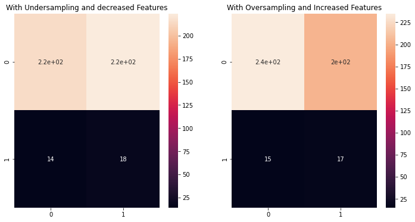

```python
plt.figure(figsize=(12,6))
plt.subplot(1,2,1)
sns.heatmap(confusion_matrix_list[Model],annot=True)
plt.title("With Undersampling and decreased Features")
plt.subplot(1,2,2)
sns.heatmap(confusion_matrix_list2[Model2],annot=True)
plt.title("With Oversampling and Increased Features")
plt.show()
```

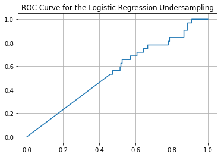

```python
plt.plot(roc_characteristics["False_positive_rate"],roc_characteristics["True_positive_rate"])
plt.grid(True)
plt.title("ROC Curve for the Logistic Regression Undersampling")
```

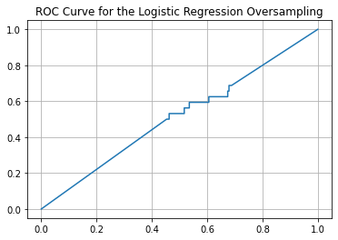

```python
plt.plot(roc_characteristics2["False_positive_rate"],roc_characteristics2["True_positive_rate"])
plt.grid(True)
plt.title("ROC Curve for the Logistic Regression Oversampling")
```

**Observations** : This looks like a Terrible model. So, we are going to abandon it. There might be several reasons for it, especially like the addition of synthetic data and I am strongly in favour of it. Generating Synthetic data doesn't seem to do any better for the model. It only made it look good on train score but performed equally in test score. That should be a point to note. Or perhaps this whole model choice itself is a disaster.

```python
#########################################################################
#
# This takes a list of models, generates data for them and then sends out
# parameters.
#
# Writing a function to cover the above in a pipeline if we want.
#########################################################################
#########################################################################
def Model_fitting_parameter_extraction(X_train,y_train,X_test,y_test,list_of_models):
    #################################################################
    from sklearn.metrics import accuracy_score
    from sklearn.metrics import recall_score
    from sklearn.metrics import recall_score
    from sklearn.metrics import classification_report
    from sklearn.metrics import roc_auc_score as area_under_curve
    from sklearn.metrics import roc_curve, auc
    ###################################################################
    comparison_of_models_matrix=[]
    classification_report_list={}
    confusion_matrix_list={}
    roc_characteristics={}
    ###################################################################
    #
    ########################################################################
    #########################################################################
    for Model in list_of_models:
        Model.fit(X_train,y_train)
        #print("Step 1 : Finished")
        Model_prediction=Model.predict(X_test)
        train_score=Model.score(X_train,y_train)
        test_score=Model.score(X_test,y_test)
        Accuracy=accuracy_score(y_test,Model_prediction)
        Recall=recall_score(y_test,Model_prediction)
        area=area_under_curve(y_test,Model_prediction)
        probability=Model.predict_proba(X_test)
        #print(probability.shape)
        False_p_rate,True_p_rate,thresh=roc_curve(np.array(y_test.ravel()),probability[:,1])
        #print("Step 2 : Finished")
        confusion_matrix_list.update({Model:metrics.confusion_matrix(y_test, Model_prediction, labels=[-1, 1])})
        #print("Step 3 : Finished")
        comparison_of_models_matrix.append({"Model":Model,
                                    "Train_score":train_score,
                                    "Test_score":test_score,"Accuracy":Accuracy,"Recall":Recall,"ROC_AUC":area})
        #print("Step 4 : Finished")
        #comparison_of_models_matrix.update(model_information(X_train,y_train,X_test,y_test,Model_prediction))
        #print("Step 5 : Finished")
        roc_characteristics.update({"False_psotive_rate":False_p_rate,
                                           "True_positive_rate": True_p_rate,"Threshold_rate":thresh})
        classification_report_list.update({"Model":Model,
                                   "classification_report":classification_report(y_test, Model_prediction, labels=[-1, 1])})
    ########################################################################
    return [comparison_of_models_matrix,classification_report_list,confusion_matrix_list,roc_characteristics]
########################################################################
########################################################################
```

```python
########################################################################
#########################################################################
#This function takes a list of confusion matrices from all the models and
#gives out a nice dataframe. We can add further functions to this to create
# and add new featues which is given as a comment here. Define the new
# functions that return a pandas series given the confusion matrix, we can
# always create new ways.
##########################################################################
###########################################################################
def confusion_matrix_df(confusion_matrix_given):
    confusion_df_all=pd.DataFrame(confusion_matrix_given,columns=["TP","FP","FN","TN"])
    #print(confusion_df_all)
    true_p=confusion_df_all["TP"]
    false_p=confusion_df_all["FP"]
    false_n=confusion_df_all["FN"]
    true_n=confusion_df_all["TN"]
    confusion_df_all["Precision"]=true_p/(true_p+false_p)
    return confusion_df_all

#################################################################################
##################################################################################
#confusion_matrix_taken=[confusion_matrix_list[x] for x in confusion_matrix_list]
####################################################################################

#Model_comparison=pd.DataFrame(comparison_of_models_matrix,index=["Model"])
#Model_comparison.drop_duplicates(subset="Model",inplace=True)
#Model_complete=Model_comparison.join(confusion_matrix_df(confusion_matrix_taken))
##################################################################################
# We need to have more than one model to have a good dataframe of comparison.
# This is built for that purpose.
#Model_complete
```

We can use the above functions, or simply use a wrapper that encloses both the above functions that outputs the dataframe or use it individually. It is given below.

We can even give this wrapper to the Hyperparameter tuning functions so that we get best choice for best parameters and best models for the data. But, a computer needs to be extremely powerful to tackle it. So, just leaving it as a choice.

```python
#################################################################################
##################################################################################
def complete_df_models(X_train,y_train,X_test,y_test,Models_list):
    dtta=[]
    dtta=Model_fitting_parameter_extraction(X_train,y_train,X_test,y_test,Models_list)
    confusion_matrix_list=[]
    #######################################################################
    for key in dtta[2]:
        #print(key)
        #print(dtta[2][key])
        confusion_matrix_list.append(dtta[2][key].ravel())
    #print(confusion_matrix_list)
    ####################################################################################
    Model_comparison=pd.DataFrame(dtta[0])
    #Model_comparison.drop_duplicates(subset="Model",inplace=True)
    Model_complete=Model_comparison.join(confusion_matrix_df(confusion_matrix_list))
    Model_complete["f1_score"]=2*(Model_complete["Precision"]*Model_complete["Recall"])/(Model_complete["Precision"]+Model_complete["Recall"])
    ##################################################################################
    return Model_complete#,dtta
#################################################################################
##################################################################################
```

```python
#Reinitialize-the Data before we go pipelining example and a whole lot of things.
x=data1_final.drop("Pass/Fail",axis=1) # The rest four columns create our independent columns
y=data1_final["Pass/Fail"]

X_train, X_test, y_train, y_test = train_test_split(x, y, test_size=0.30, random_state=random_state)
```

Before going ahead, we need to recheck what are all the Models available to us and, what their parameters are. Then generate a pipeline for each of those models.

Subject the whole GridSearchCV to those pipelines and then comeup with best model and then best parameters for that particular model.

**Please Note** : In the view of the computation time involved, it has been decided to check only 3 models.

# 7. Cross Validation and Hyperparameter Tuning

```python
#######################################################################
###### STAGE 7 ########################################################
#######################################################################
```

```python
for key in Models_list:
    print(key) #Printing models available for us
```

```
LogisticRegression
NaiveBayes
KNN
support_vector
decision_tree
bagging
adaboost
gradientboost
random_forest
MLPC
NuSVC
```

```python
choice_models=["KNN","random_forest","NaiveBayes"]
# Before going ahead, we need to check parameters. But only first 3 Models are being considered here.
# If you want to add more to the pipe, add them here, but be sure to make the parameters
# variations ready so that you can later feed them to the gridsearch Cv for model tuning.
############################################################
for key in choice_models:
    #print("\n")
    print(key,"\n")
    #print("\n")
    print(Models_list[key].get_params())
    print("\n")
############################################################
```

```
KNN

{'algorithm': 'auto', 'leaf_size': 30, 'metric': 'minkowski', 'metric_params': None, 'n_jobs': None, 'n_neighbors': 5, 'p': 2, 'weights': 'uniform'}


random_forest

{'bootstrap': True, 'ccp_alpha': 0.0, 'class_weight': None, 'criterion': 'gini', 'max_depth': None, 'max_features': 'auto', 'max_leaf_nodes': None, 'max_samples': None, 'min_impurity_decrease': 0.0, 'min_impurity_split': None, 'min_samples_leaf': 1, 'min_samples_split': 2, 'min_weight_fraction_leaf'…


NaiveBayes

{'priors': None, 'var_smoothing': 1e-09}
```

```python
from scipy.stats import randint as sp_randint
######################################################################
parameters={"KNN":{'n_neighbors': list(range(1,20)),
             'algorithm': ('auto', 'ball_tree', 'kd_tree' , 'brute')},

            "random_forest":{"max_depth":[3, None],
              "n_estimators":range(1,50),
              "max_features": sp_randint(1, 11),
              "min_samples_split": sp_randint(2, 11),
              "min_samples_leaf": sp_randint(1, 11),
              "criterion": ["gini", "entropy"]},

            "NaiveBayes":{}}
######################################################################
#NOte that NiaveBayes doesn't have any significant parameters, I choose it that way so
#that time can be saved.
```

```python
###################################################################
#Here we just demonstrate the use of these Cross validation parameters
#
#################################################################
from sklearn.model_selection import GridSearchCV
from sklearn.model_selection import cross_val_score
from sklearn.datasets import load_digits
##################################################################
#GridSearch CV
##################################################################
##################################################################
gs = GridSearchCV(KNN,param_grid=parameters["KNN"],cv=10)
#####################################################################
gs.fit(X_train, y_train)
print(gs.best_params_) #Automatically gives best parameters
#print(gs.cv_results_['params'])
#print(gs.cv_results_['mean_test_score'])
####################################################################
####################################################################
#
#Randomized Search CV
###################################################################
#####################################################################
from sklearn.model_selection import RandomizedSearchCV

####################################################################
####################################################################
# run randomized search
samples = 10  # number of random samples
randomCV = RandomizedSearchCV(random_forest, param_distributions=parameters["random_forest"], n_iter=samples) #default cv = 3
#######################################################################
randomCV.fit(X_train, y_train)
print(randomCV.best_params_)
######################################################################
######################################################################
```

```
{'algorithm': 'auto', 'n_neighbors': 4}
{'criterion': 'entropy', 'max_depth': None, 'max_features': 5, 'min_samples_leaf': 1, 'min_samples_split': 6, 'n_estimators': 7}
```